# Transform a data frame

# From wide to long

## `pivot_longer()`

- `cols`: The columns to be aggregated into a new variable.
- `names_to`: The name of the new variable containing the names of the aggregated columns.
- `values_to`: The name of the variable containing the values of the aggregated columns.

**Wide format:**

```
  player year1 year2
1      A    12    22
2      B    15    29
3      C    19    18
4      D    19    12
```

**Long format:**

```r
pivot_longer(
  df,
  cols = 2:3,
  names_to = 'year',
  values_to = 'points'
)
# A tibble: 8 × 3
  player year  points
  <chr>  <chr>  <dbl>
1 A      year1     12
2 A      year2     22
3 B      year1     15
4 B      year2     29
5 C      year1     19
6 C      year2     18
7 D      year1     19
8 D      year2     12
```

## Task

Take the `billboard` dataset (package tidyverse/tidyr). It looks like this:

| artist | track | date.entered | wk1 | wk2 | wk3 | wk4 | wk5 | wk6 | wk7 | wk8 | wk9 | wk10 | wk11 | wk12 | wk13 | wk14 | wk15 | wk16 | wk17 | wk18 | wk19 | wk20 | wk21 | wk22 | wk23 | wk24 | wk25 | wk26 | wk27 | … |
| --- | --- | --- | --- | --- | --- | --- | --- | --- | --- | --- | --- | --- | --- | --- | --- | --- | --- | --- | --- | --- | --- | --- | --- | --- | --- | --- | --- | --- | --- | --- |
| 2 Pac | Baby Don't Cry (Keep... | 2000-02-26 | 87 | 82 | 72 | 77 | 87 | 94 | 99 | NA | NA | NA | NA | NA | NA | NA | NA | NA | NA | NA | NA | NA | NA | NA | NA | NA | NA | NA | NA | … |
| 2Ge+her | The Hardest Part Of ... | 2000-09-02 | 91 | 87 | 92 | NA | NA | NA | NA | NA | NA | NA | NA | NA | NA | NA | NA | NA | NA | NA | NA | NA | NA | NA | NA | NA | NA | NA | NA | … |
| 3 Doors Down | Kryptonite | 2000-04-08 | 81 | 70 | 68 | 67 | 66 | 57 | 54 | 53 | 51 | 51 | 51 | 51 | 47 | 44 | 38 | 28 | 22 | 18 | 18 | 14 | 12 | 7 | 6 | 6 | 6 | 5 | 5 | … |
| 3 Doors Down | Loser | 2000-10-21 | 76 | 76 | 72 | 69 | 67 | 65 | 55 | 59 | 62 | 61 | 61 | 59 | 61 | 66 | 72 | 76 | 75 | 67 | 73 | 70 | NA | NA | NA | NA | NA | NA | NA | … |
| 504 Boyz | Wobble Wobble | 2000-04-15 | 57 | 34 | 25 | 17 | 17 | 31 | 36 | 49 | 53 | 57 | 64 | 70 | 75 | 76 | 78 | 85 | 92 | 96 | NA | NA | NA | NA | NA | NA | NA | NA | NA | … |
| 98^0 | Give Me Just One Nig... | 2000-08-19 | 51 | 39 | 34 | 26 | 26 | 19 | 2 | 2 | 3 | 6 | 7 | 22 | 29 | 36 | 47 | 67 | 66 | 84 | 93 | 94 | NA | NA | NA | NA | NA | NA | NA | … |
| A*Teens | Dancing Queen | 2000-07-08 | 97 | 97 | 96 | 95 | 100 | NA | NA | NA | NA | NA | NA | NA | NA | NA | NA | NA | NA | NA | NA | NA | NA | NA | NA | NA | NA | NA | NA | … |
| Aaliyah | I Don't Wanna | 2000-01-29 | 84 | 62 | 51 | 41 | 38 | 35 | 35 | 38 | 38 | 36 | 37 | 37 | 38 | 49 | 61 | 63 | 62 | 67 | 83 | 86 | NA | NA | NA | NA | NA | NA | NA | … |
| Aaliyah | Try Again | 2000-03-18 | 59 | 53 | 38 | 28 | 21 | 18 | 16 | 14 | 12 | 10 | 9 | 8 | 6 | 1 | 2 | 2 | 2 | 2 | 3 | 4 | 5 | 5 | 6 | 9 | 13 | 14 | 16 | … |
| Adams, Yolanda | Open My Heart | 2000-08-26 | 76 | 76 | 74 | 69 | 68 | 67 | 61 | 58 | 57 | 59 | 66 | 68 | 61 | 67 | 59 | 63 | 67 | 71 | 79 | 89 | NA | NA | NA | NA | NA | NA | NA | … |

[output cut: 307 more lines]

Use the `pivot_longer()` function to create a dataset that looks like this:

| artist | track | date.entered | week | position |
| --- | --- | --- | --- | --- |
| 2 Pac | Baby Don't Cry (Keep... | 2000-02-26 | wk1 | 87 |
| 2 Pac | Baby Don't Cry (Keep... | 2000-02-26 | wk2 | 82 |
| 2 Pac | Baby Don't Cry (Keep... | 2000-02-26 | wk3 | 72 |
| 2 Pac | Baby Don't Cry (Keep... | 2000-02-26 | wk4 | 77 |
| 2 Pac | Baby Don't Cry (Keep... | 2000-02-26 | wk5 | 87 |
| 2 Pac | Baby Don't Cry (Keep... | 2000-02-26 | wk6 | 94 |
| 2 Pac | Baby Don't Cry (Keep... | 2000-02-26 | wk7 | 99 |
| 2Ge+her | The Hardest Part Of ... | 2000-09-02 | wk1 | 91 |
| 2Ge+her | The Hardest Part Of ... | 2000-09-02 | wk2 | 87 |
| 2Ge+her | The Hardest Part Of ... | 2000-09-02 | wk3 | 92 |

[output cut: 5297 more lines]

```r
billboard %>%
  pivot_longer(starts_with("wk"), names_to = "week",
               values_to = "position", values_drop_na = TRUE)
# A tibble: 5,307 × 5
   artist  track                   date.entered week  position
   <chr>   <chr>                   <date>       <chr>    <dbl>
 1 2 Pac   Baby Don't Cry (Keep... 2000-02-26   wk1         87
 2 2 Pac   Baby Don't Cry (Keep... 2000-02-26   wk2         82
 3 2 Pac   Baby Don't Cry (Keep... 2000-02-26   wk3         72
 4 2 Pac   Baby Don't Cry (Keep... 2000-02-26   wk4         77
 5 2 Pac   Baby Don't Cry (Keep... 2000-02-26   wk5         87
 6 2 Pac   Baby Don't Cry (Keep... 2000-02-26   wk6         94
 7 2 Pac   Baby Don't Cry (Keep... 2000-02-26   wk7         99
 8 2Ge+her The Hardest Part Of ... 2000-09-02   wk1         91
 9 2Ge+her The Hardest Part Of ... 2000-09-02   wk2         87
10 2Ge+her The Hardest Part Of ... 2000-09-02   wk3         92
# … with 5,297 more rows
# ℹ Use `print(n = ...)` to see more rows
```

**Wide format:**

```
   id dia sys anxious happy sad
1   1 161 105       4     2   1
2   2 127  90       2     3   1
3   3 135 100       2     2   3
4   4 148  93       1     1   3
5   5 148 105       2     1   5
6   6 141  97       5     4   4
7   7 140 100       5     5   2
8   8 113  85       2     4   5
9   9 129  84       3     4   2
10 10 164 121       5     2   1
11 11 160 104       4     3   4
12 12 175 116       4     1   2
13 13 109  70       1     5   3
14 14 163 110       4     2   4
```

[output cut: 16 more lines]

```r
df %>%
  pivot_longer(cols = 2:3,
               names_to = 'bp_type',
               values_to = 'pressure') %>%
  pivot_longer(cols = c("anxious", "happy", "sad"),
               names_to = 'emotion',
               values_to = 'emotion_value')
# A tibble: 180 × 5
      id bp_type pressure emotion emotion_value
   <int> <chr>      <dbl> <chr>           <int>
 1     1 dia          161 anxious             4
 2     1 dia          161 happy               2
 3     1 dia          161 sad                 1
 4     1 sys          105 anxious             4
 5     1 sys          105 happy               2
 6     1 sys          105 sad                 1
 7     2 dia          127 anxious             2
 8     2 dia          127 happy               3
 9     2 dia          127 sad                 1
10     2 sys           90 anxious             2
# … with 170 more rows
# ℹ Use `print(n = ...)` to see more rows
```

## Task: Create this plot:

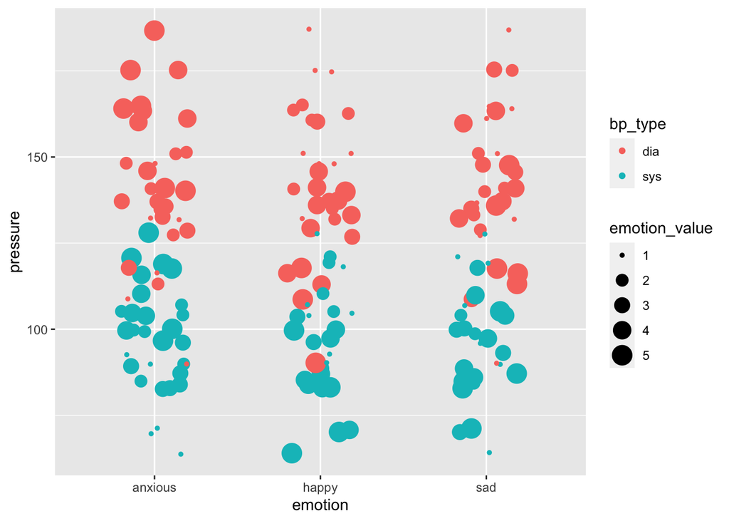

- Load the dataset with:

```r
download.file("https://raw.githubusercontent.com/jazznbass/datasets/main/bp_example.csv",
    destfile = "example.csv", method = "curl")
df <- read.csv("example.csv")
```

- Turn the df into a long format as described on the previous slide.
- use ggplot: Aesthetics: x = emotion, y = pressure, color = bp_type, size = emotion_value.
- Add a jitter geom with width 0.2.

**Step 1:**

```r
df_long <- df %>%
  pivot_longer(cols = 2:3,
               names_to = 'bp_type',
               values_to = 'pressure') %>%
  pivot_longer(cols = c("anxious", "happy", "sad"),
               names_to = 'emotion',
               values_to = 'emotion_value')
df_long
# A tibble: 180 × 5
      id bp_type pressure emotion emotion_value
   <int> <chr>      <dbl> <chr>           <int>
 1     1 dia          161 anxious             4
 2     1 dia          161 happy               2
 3     1 dia          161 sad                 1
 4     1 sys          105 anxious             4
 5     1 sys          105 happy               2
 6     1 sys          105 sad                 1
 7     2 dia          127 anxious             2
 8     2 dia          127 happy               3
 9     2 dia          127 sad                 1
10     2 sys           90 anxious             2
# … with 170 more rows
# ℹ Use `print(n = ...)` to see more rows
```

**Step 2:**

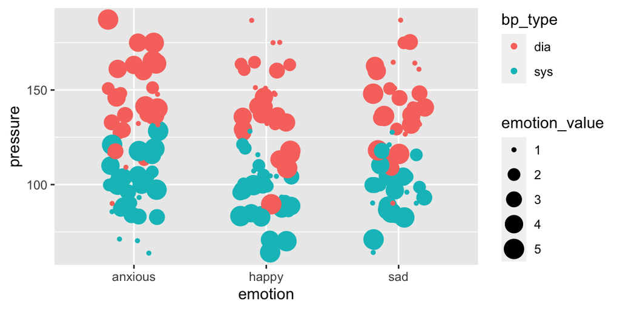

```r
ggplot(df_long,
  aes(x = emotion, y = pressure,
      color = bp_type, size = emotion_value)) +
  geom_jitter(width = 0.2)
```

## Complex example

We have such a dataframe:

| religion | <$10k | $10-20k | $20-30k | $30-40k | $40-50k | $50-75k | $75-100k | $100-150k | >150k | Don’t know/refused |
| --- | --- | --- | --- | --- | --- | --- | --- | --- | --- | --- |
| Agnostic | 27 | 34 | 60 | 81 | 76 | 137 | 122 | 109 | 84 | 96 |
| Atheist | 12 | 27 | 37 | 52 | 35 | 70 | 73 | 59 | 74 | 76 |
| Buddhist | 27 | 21 | 30 | 34 | 33 | 58 | 62 | 39 | 53 | 54 |
| Catholic | 418 | 617 | 732 | 670 | 638 | 1116 | 949 | 792 | 633 | 1489 |
| Don’t know/refused | 15 | 14 | 15 | 11 | 10 | 35 | 21 | 17 | 18 | 116 |
| Evangelical Prot | 575 | 869 | 1064 | 982 | 881 | 1486 | 949 | 723 | 414 | 1529 |
| Hindu | 1 | 9 | 7 | 9 | 11 | 34 | 47 | 48 | 54 | 37 |
| Historically Black Prot | 228 | 244 | 236 | 238 | 197 | 223 | 131 | 81 | 78 | 339 |
| Jehovah’s Witness | 20 | 27 | 24 | 24 | 21 | 30 | 15 | 11 | 6 | 37 |
| Jewish | 19 | 19 | 25 | 25 | 30 | 95 | 69 | 87 | 151 | 162 |
| Mainline Prot | 289 | 495 | 619 | 655 | 651 | 1107 | 939 | 753 | 634 | 1328 |
| Mormon | 29 | 40 | 48 | 51 | 56 | 112 | 85 | 49 | 42 | 69 |
| Muslim | 6 | 7 | 9 | 10 | 9 | 23 | 16 | 8 | 6 | 22 |
| Orthodox | 13 | 17 | 23 | 32 | 32 | 47 | 38 | 42 | 46 | 73 |
| Other Christian | 9 | 7 | 11 | 13 | 13 | 14 | 18 | 14 | 12 | 18 |
| Other Faiths | 20 | 33 | 40 | 46 | 49 | 63 | 46 | 40 | 41 | 71 |
| Other World Religions | 5 | 2 | 3 | 4 | 2 | 7 | 3 | 4 | 4 | 8 |
| Unaffiliated | 217 | 299 | 374 | 365 | 341 | 528 | 407 | 321 | 258 | 597 |

## We want such a plot:

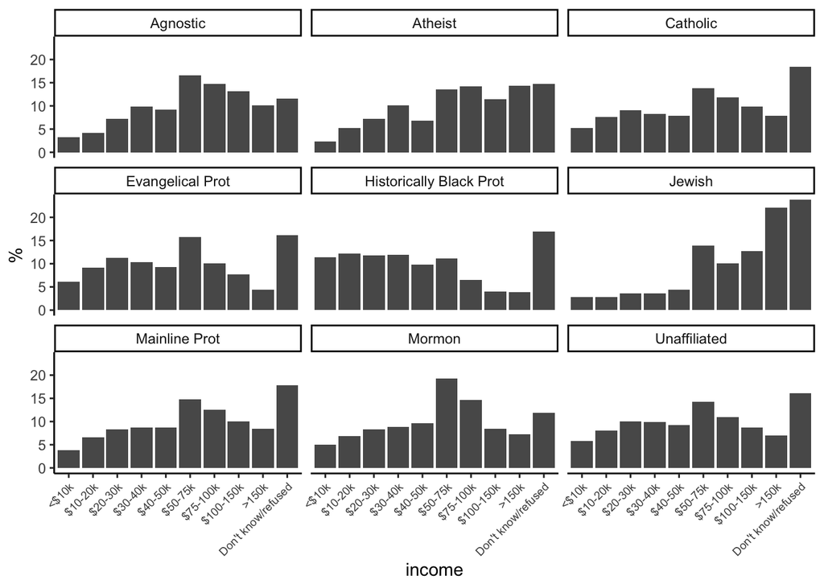

## Step 1: Turn the count values into percentages:

```r
# with dplyr:
new_df <- relig_income %>%
  rowwise() %>%
  mutate(total = sum(c_across(2:11))) %>%
  ungroup() %>%
  mutate(across(2:11, ~ . / total * 100)) %>%
  filter(total >= 500)
```

```r
# with base R
new_df <- as.data.frame(relig_income)
new_df$total <- apply(new_df[, 2:11], 1, sum)
new_df <- new_df[new_df$total >= 500,]

for(i in 1:nrow(new_df))
  new_df[i, 2:11] <- new_df[i, 2:11] / new_df$total[i] * 100
```

|  | religion | <$10k | $10-20k | $20-30k | $30-40k | $40-50k | $50-75k | $75-100k | $100-150k | >150k | Don’t know/refused | total |
| --- | --- | --- | --- | --- | --- | --- | --- | --- | --- | --- | --- | --- |
| 1 | Agnostic | 3.268765 | 4.116223 | 7.263922 | 9.806295 | 9.200969 | 16.58596 | 14.769976 | 13.196126 | 10.169491 | 11.62228 | 826 |
| 2 | Atheist | 2.330097 | 5.242718 | 7.184466 | 10.097087 | 6.796117 | 13.59223 | 14.174757 | 11.456311 | 14.368932 | 14.75728 | 515 |
| 4 | Catholic | 5.189968 | 7.660790 | 9.088652 | 8.318848 | 7.921530 | 13.85647 | 11.782965 | 9.833623 | 7.859449 | 18.48771 | 8054 |
| 6 | Evangelical Prot | 6.070524 | 9.174409 | 11.233108 | 10.367399 | 9.301098 | 15.68834 | 10.019003 | 7.633024 | 4.370777 | 16.14231 | 9472 |
| 8 | Historically Black Prot | 11.428571 | 12.230576 | 11.829574 | 11.929825 | 9.874687 | 11.17794 | 6.566416 | 4.060150 | 3.909774 | 16.99248 | 1995 |
| 10 | Jewish | 2.785924 | 2.785924 | 3.665689 | 3.665689 | 4.398827 | 13.92962 | 10.117302 | 12.756598 | 22.140763 | 23.75367 | 682 |
| 11 | Mainline Prot | 3.868809 | 6.626506 | 8.286479 | 8.768407 | 8.714859 | 14.81928 | 12.570281 | 10.080321 | 8.487282 | 17.77778 | 7470 |
| 12 | Mormon | 4.991394 | 6.884682 | 8.261618 | 8.777969 | 9.638554 | 19.27711 | 14.629948 | 8.433735 | 7.228916 | 11.87608 | 581 |
| 18 | Unaffiliated | 5.853790 | 8.065821 | 10.089021 | 9.846237 | 9.198813 | 14.24332 | 10.979228 | 8.659293 | 6.959806 | 16.10467 | 3707 |

## Step 2: Turn data into long format:

```r
# tidy R
new_long <- new_df %>%
  pivot_longer(col = 2:11, names_to = "income", values_to = "count")


#  base R:
new_long <- data.frame(
  religion = rep(NA, nrow(new_df) * 10),
  income = rep(names(new_df)[2:11], nrow(new_df)),
  count = rep(NA, nrow(new_df) * 10))

new_long$religion <- rep(new_df$religion, each = 10)

for(i in 1:nrow(new_df))
  new_long$count[((i-1)*10+1):((i-1)*10+10)] <- as.numeric(new_df[i, 2:11])
```

| religion | income | count |
| --- | --- | --- |
| Agnostic | <$10k | 3.268765 |
| Agnostic | $10-20k | 4.116223 |
| Agnostic | $20-30k | 7.263922 |
| Agnostic | $30-40k | 9.806295 |
| Agnostic | $40-50k | 9.200969 |
| Agnostic | $50-75k | 16.585956 |
| Agnostic | $75-100k | 14.769976 |
| Agnostic | $100-150k | 13.196126 |
| Agnostic | >150k | 10.169491 |
| Agnostic | Don’t know/refused | 11.622276 |
| Atheist | <$10k | 2.330097 |
| Atheist | $10-20k | 5.242718 |
| Atheist | $20-30k | 7.184466 |
| Atheist | $30-40k | 10.097087 |
| Atheist | $40-50k | 6.796117 |
| Atheist | $50-75k | 13.592233 |
| Atheist | $75-100k | 14.174757 |
| Atheist | $100-150k | 11.456311 |
| Atheist | >150k | 14.368932 |
| Atheist | Don’t know/refused | 14.757282 |
| Catholic | <$10k | 5.189968 |
| Catholic | $10-20k | 7.660790 |
| Catholic | $20-30k | 9.088652 |
| Catholic | $30-40k | 8.318848 |
| Catholic | $40-50k | 7.921530 |
| Catholic | $50-75k | 13.856469 |
| Catholic | $75-100k | 11.782965 |
| Catholic | $100-150k | 9.833623 |
| Catholic | >150k | 7.859449 |
| Catholic | Don’t know/refused | 18.487708 |

[output cut: 60 more lines]

## Create the basic plot

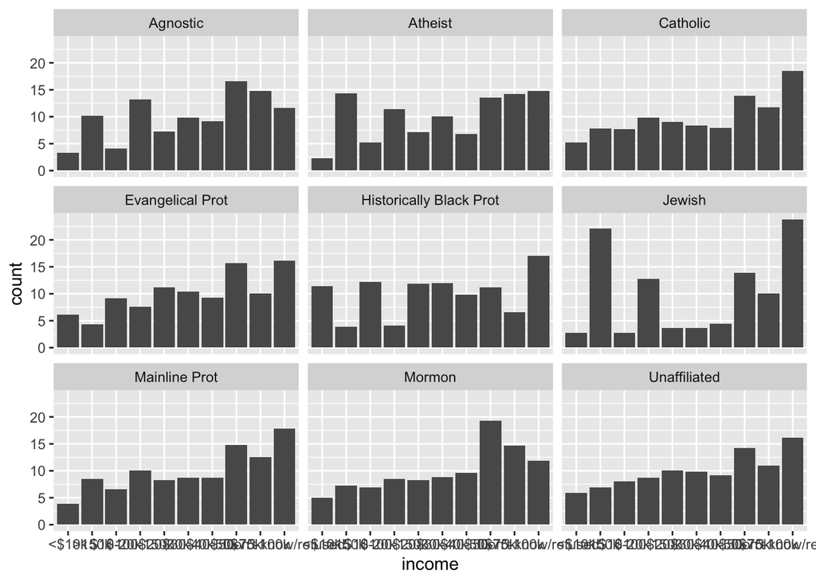

```r
new_long %>%
  ggplot(aes(x = income, y = count)) +
  geom_col() +
  facet_wrap(~religion)
```

## Rotate the text and set a label

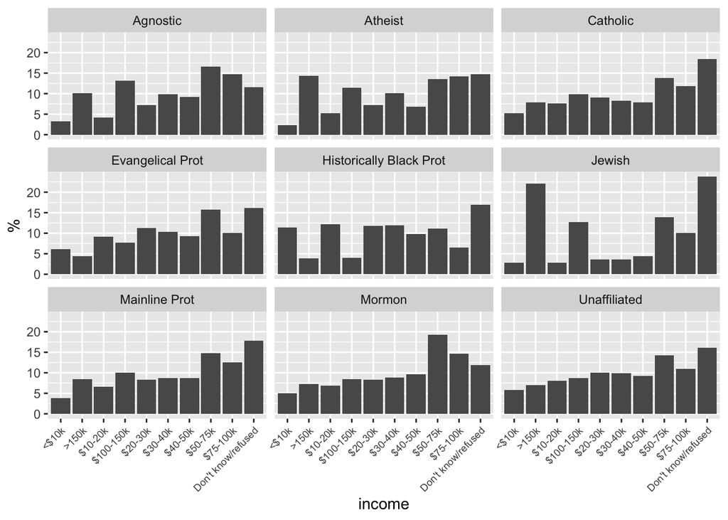

```r
new_long %>%
  ggplot(aes(x = income, y = count)) +
  geom_col() +
  facet_wrap(~religion) +
  theme(axis.text.x = element_text(angle = 45, size = 7, hjust = 1)) +
  ylab("%")
```

## Reorder income

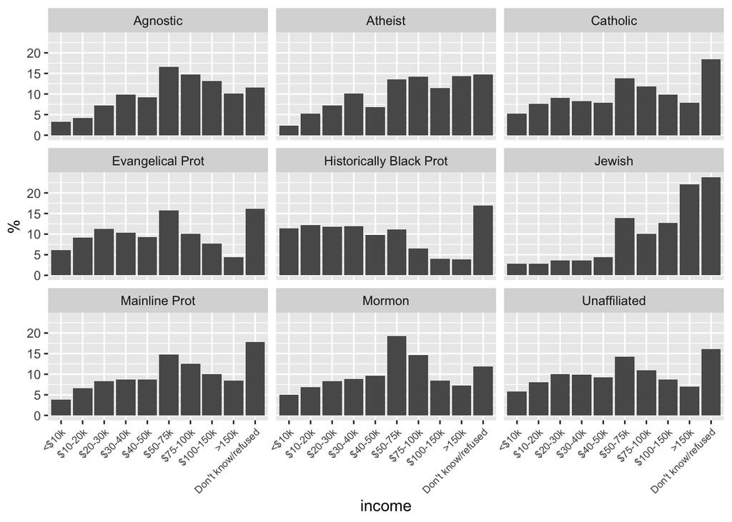

```r
new_long %>%
  mutate(income = factor(income, levels = names(relig_income)[2:11])) %>%
  ggplot(aes(x = income, y = count)) +
  geom_col() +
  facet_wrap(~religion) +
  theme(axis.text.x = element_text(angle = 45, size = 7, hjust = 1)) +
  ylab("%")
```

## Set a nice theme

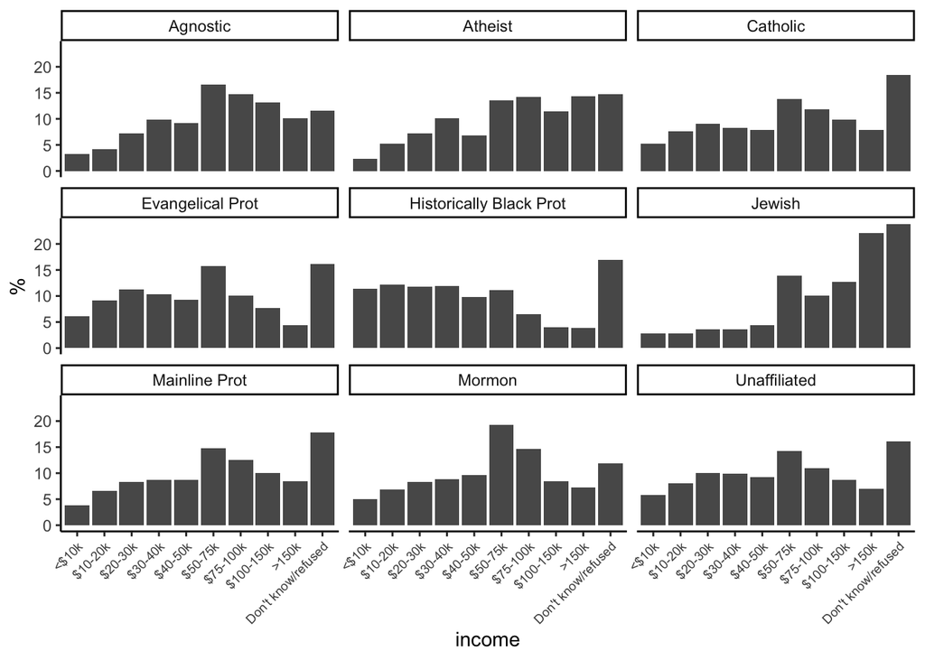

```r
new_long %>%
  mutate(income = factor(income, levels = names(relig_income)[2:11])) %>%
  ggplot(aes(x = income, y = count)) +
  geom_col() +
  facet_wrap(~religion) +
  theme_classic() +
  theme(axis.text.x = element_text(angle = 45, size = 7, hjust = 1)) +
  ylab("%")
```

# Join datasets

## `full_join()`

Joins to datasets:

- `x` and `y`: Two dataset objects.
- `by`: A columnname by which the datasets are joined.

## Example

```
   age sex T_score class_id
1    5   F      32        A
2    7   M      56        A
3   10   M      58        A
4    7   F      39        B
5    7   F      45        B
6   10   F      35        B
7    6   M      61        C
8   10   M      51        C
9    7   F      38        C
10   9   F      57        D
11  10   F      65        D
12   6   M      60        D
```

```
  class_id self_efficacy
1        A            56
2        B            57
3        C            64
4        D            68
```

```r
full_join(df_student, df_teacher, by = "class_id")
```

```
   age sex T_score class_id self_efficacy
1    5   F      32        A            56
2    7   M      56        A            56
3   10   M      58        A            56
4    7   F      39        B            57
5    7   F      45        B            57
6   10   F      35        B            57
7    6   M      61        C            64
8   10   M      51        C            64
9    7   F      38        C            64
10   9   F      57        D            68
11  10   F      65        D            68
12   6   M      60        D            68
```

## Example

```
   age sex T_score class_id
1   10   F      68        A
2   10   F      35        A
3    8   M      33        A
4    9   F      40        B
5    6   M      61        B
6    7   F      66        B
7    6   M      47        C
8    7   M      37        C
9    6   M      39        C
10   7   F      64        D
11   9   M      45        D
12   7   M      59        D
```

```
  class_id self_efficacy age sex
1        A            38  26   F
2        B            34  45   F
3        C            64  31   M
4        D            38  42   M
```

```r
full_join(df_student, df_teacher, by = "class_id")
```

```
   age.x sex.x T_score class_id self_efficacy age.y sex.y
1     10     F      68        A            38    26     F
2     10     F      35        A            38    26     F
3      8     M      33        A            38    26     F
4      9     F      40        B            34    45     F
5      6     M      61        B            34    45     F
6      7     F      66        B            34    45     F
7      6     M      47        C            64    31     M
8      7     M      37        C            64    31     M
9      6     M      39        C            64    31     M
10     7     F      64        D            38    42     M
11     9     M      45        D            38    42     M
12     7     M      59        D            38    42     M
```

## Example

```r
full_join(df_student, df_teacher, by = "class_id", suffix = c("_student", "_teacher"))
```

| age_student | sex_student | T_score | class_id | self_efficacy | age_teacher | sex_teacher |
| --- | --- | --- | --- | --- | --- | --- |
| 10 | F | 68 | A | 38 | 26 | F |
| 10 | F | 35 | A | 38 | 26 | F |
| 8 | M | 33 | A | 38 | 26 | F |
| 9 | F | 40 | B | 34 | 45 | F |
| 6 | M | 61 | B | 34 | 45 | F |
| 7 | F | 66 | B | 34 | 45 | F |
| 6 | M | 47 | C | 64 | 31 | M |
| 7 | M | 37 | C | 64 | 31 | M |
| 6 | M | 39 | C | 64 | 31 | M |
| 7 | F | 64 | D | 38 | 42 | M |
| 9 | M | 45 | D | 38 | 42 | M |
| 7 | M | 59 | D | 38 | 42 | M |

## Task

- Load the df_student and df_teacher dataset:

```r
download.file("https://raw.githubusercontent.com/jazznbass/datasets/main/df_student.csv",
    destfile = "students.csv", method = "curl")
download.file("https://raw.githubusercontent.com/jazznbass/datasets/main/df_teacher.csv",
    destfile = "teachers.csv", method = "curl")

df_students <- read.csv("students.csv")
df_teachers <- read.csv("teachers.csv")
```

- join the two datasets by class id.
- add for each student the average age and the proportion of males of the students of his class.

Hint: use group_by and summarise to calculate average age and proportions of males.

## Solution

```r
df <- full_join(df_students, df_teachers, by = "class_id", suffix = c("_student", "_teacher"))
```

| age_student | sex_student | T_score | class_id | self_efficacy | age_teacher | sex_teacher |
| --- | --- | --- | --- | --- | --- | --- |
| 9 | M | 60 | class_1 | 31 | 29 | F |
| 9 | M | 53 | class_1 | 31 | 29 | F |
| 6 | M | 70 | class_1 | 31 | 29 | F |
| 10 | M | 53 | class_1 | 31 | 29 | F |
| 7 | F | 38 | class_1 | 31 | 29 | F |
| 6 | F | 49 | class_1 | 31 | 29 | F |
| 9 | F | 57 | class_1 | 31 | 29 | F |
| 7 | F | 60 | class_1 | 31 | 29 | F |
| 6 | F | 34 | class_1 | 31 | 29 | F |
| 5 | M | 33 | class_1 | 31 | 29 | F |
| 5 | M | 65 | class_1 | 31 | 29 | F |
| 10 | F | 52 | class_1 | 31 | 29 | F |
| 9 | M | 59 | class_1 | 31 | 29 | F |
| 5 | F | 56 | class_1 | 31 | 29 | F |
| 7 | M | 53 | class_1 | 31 | 29 | F |
| 6 | F | 42 | class_1 | 31 | 29 | F |
| 8 | F | 33 | class_1 | 31 | 29 | F |
| 5 | M | 45 | class_1 | 31 | 29 | F |
| 10 | F | 69 | class_1 | 31 | 29 | F |
| 9 | M | 32 | class_1 | 31 | 29 | F |
| 9 | M | 52 | class_2 | 67 | 50 | F |
| 7 | M | 68 | class_2 | 67 | 50 | F |
| 7 | F | 44 | class_2 | 67 | 50 | F |
| 6 | M | 35 | class_2 | 67 | 50 | F |
| 6 | M | 44 | class_2 | 67 | 50 | F |
| 6 | F | 35 | class_2 | 67 | 50 | F |
| 10 | F | 33 | class_2 | 67 | 50 | F |
| 7 | F | 55 | class_2 | 67 | 50 | F |
| 6 | M | 65 | class_2 | 67 | 50 | F |
| 9 | F | 58 | class_2 | 67 | 50 | F |

[output cut: 970 more lines]

```r
df_add <- df %>%
  group_by(class_id) %>%
  summarise(
    average_age = mean(age_student, na.rm = TRUE),
    prop_male = mean(sex_student == "M") * 100
  )
```

| class_id | average_age | prop_male |
| --- | --- | --- |
| class_1 | 7.40 | 50 |
| class_10 | 7.80 | 45 |
| class_11 | 8.15 | 40 |
| class_12 | 7.55 | 45 |
| class_13 | 6.80 | 50 |
| class_14 | 7.75 | 45 |
| class_15 | 7.35 | 45 |
| class_16 | 7.30 | 55 |
| class_17 | 7.00 | 60 |
| class_18 | 7.00 | 50 |
| class_19 | 7.80 | 40 |
| class_2 | 6.95 | 50 |
| class_20 | 7.70 | 45 |
| class_21 | 7.60 | 60 |
| class_22 | 7.75 | 50 |
| class_23 | 7.50 | 55 |
| class_24 | 7.30 | 45 |
| class_25 | 7.55 | 45 |
| class_26 | 6.95 | 40 |
| class_27 | 7.60 | 65 |
| class_28 | 7.40 | 45 |
| class_29 | 7.60 | 50 |
| class_3 | 7.95 | 40 |
| class_30 | 6.90 | 45 |
| class_31 | 7.65 | 50 |
| class_32 | 8.00 | 50 |
| class_33 | 7.20 | 50 |
| class_34 | 7.70 | 70 |
| class_35 | 7.80 | 55 |
| class_36 | 8.05 | 45 |
| class_37 | 7.60 | 65 |
| class_38 | 7.45 | 70 |
| class_39 | 6.60 | 75 |
| class_4 | 7.90 | 50 |
| class_40 | 7.90 | 40 |
| class_41 | 7.25 | 60 |
| class_42 | 7.75 | 55 |
| class_43 | 7.20 | 55 |
| class_44 | 8.45 | 35 |
| class_45 | 7.75 | 55 |
| class_46 | 6.95 | 55 |
| class_47 | 7.65 | 45 |
| class_48 | 7.45 | 60 |
| class_49 | 7.65 | 50 |
| class_5 | 7.25 | 55 |
| class_50 | 7.30 | 25 |
| class_6 | 6.90 | 65 |
| class_7 | 7.45 | 50 |
| class_8 | 8.15 | 40 |
| class_9 | 7.65 | 65 |

```r
df <- full_join(df, df_add, by = "class_id")
```

| age_student | sex_student | T_score | class_id | self_efficacy | age_teacher | sex_teacher | average_age | prop_male |
| --- | --- | --- | --- | --- | --- | --- | --- | --- |
| 9 | M | 60 | class_1 | 31 | 29 | F | 7.40 | 50 |
| 9 | M | 53 | class_1 | 31 | 29 | F | 7.40 | 50 |
| 6 | M | 70 | class_1 | 31 | 29 | F | 7.40 | 50 |
| 10 | M | 53 | class_1 | 31 | 29 | F | 7.40 | 50 |
| 7 | F | 38 | class_1 | 31 | 29 | F | 7.40 | 50 |
| 6 | F | 49 | class_1 | 31 | 29 | F | 7.40 | 50 |
| 9 | F | 57 | class_1 | 31 | 29 | F | 7.40 | 50 |
| 7 | F | 60 | class_1 | 31 | 29 | F | 7.40 | 50 |
| 6 | F | 34 | class_1 | 31 | 29 | F | 7.40 | 50 |
| 5 | M | 33 | class_1 | 31 | 29 | F | 7.40 | 50 |

[output cut: 990 more lines]